# Discovery Cohort WGCNA Analysis

# Data QC

```
## here() starts at /gfs/devel/majackson/BRC_WGCNA/Clean_Repo/Bulk_RNA_Analyses
```

```
## Allowing multi-threading with up to 20 threads.
```

## Genes

TPM expression data loaded contains **99** samples and **57885** genes. This was filtered to only retain genes observed in at least 50% of samples, resulting in **22201** genes. TPM counts were then log transformed *(log(x+1))* for further analyses.

## Samples

Removed samples flagged for omission after failing QC in DE analysis, data now contains **82** samples. Heirarchical clustering plot to check for outliers and metadata associations.

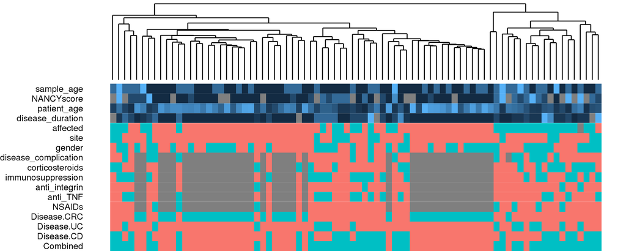

No obvious outliers, reasonable clustering of control and IBD samples.

# WGCNA

## Define co-expression modules

Find a soft-threshold power to define a network between the genes. Using signed weights to define the network.

```
## pickSoftThreshold: will use block size 2015.
##  pickSoftThreshold: calculating connectivity for given powers...
##    ..working on genes 1 through 2015 of 22201
##    ..working on genes 2016 through 4030 of 22201
##    ..working on genes 4031 through 6045 of 22201
##    ..working on genes 6046 through 8060 of 22201
##    ..working on genes 8061 through 10075 of 22201
##    ..working on genes 10076 through 12090 of 22201
##    ..working on genes 12091 through 14105 of 22201
##    ..working on genes 14106 through 16120 of 22201
##    ..working on genes 16121 through 18135 of 22201
##    ..working on genes 18136 through 20150 of 22201
##    ..working on genes 20151 through 22165 of 22201
##    ..working on genes 22166 through 22201 of 22201
##    Power SFT.R.sq slope truncated.R.sq  mean.k. median.k. max.k.
## 1      1  0.00113  1.29          0.951 11300.00  11300.00  12100
## 2      2  0.00805 -1.76          0.963  5940.00   5910.00   6960
## 3      3  0.15100 -4.26          0.949  3220.00   3190.00   4210
## 4      4  0.26300 -3.79          0.943  1800.00   1770.00   2660
## 5      5  0.38700 -3.41          0.942  1040.00   1000.00   1750
## 6      6  0.52400 -2.95          0.933   613.00    582.00   1200
## 7      7  0.70200 -3.09          0.956   373.00    344.00    904
## 8      8  0.81900 -3.06          0.980   233.00    207.00    716
## 9      9  0.88500 -2.90          0.990   150.00    126.00    583
## 10    10  0.91200 -2.74          0.992    98.70     78.20    486
## 11    12  0.93600 -2.45          0.991    46.40     31.40    354
## 12    14  0.94500 -2.22          0.991    24.00     13.20    269
## 13    16  0.93900 -2.07          0.986    13.50      5.82    211
## 14    18  0.93900 -1.94          0.984     8.18      2.65    170
## 15    20  0.94300 -1.82          0.987     5.26      1.25    139
```

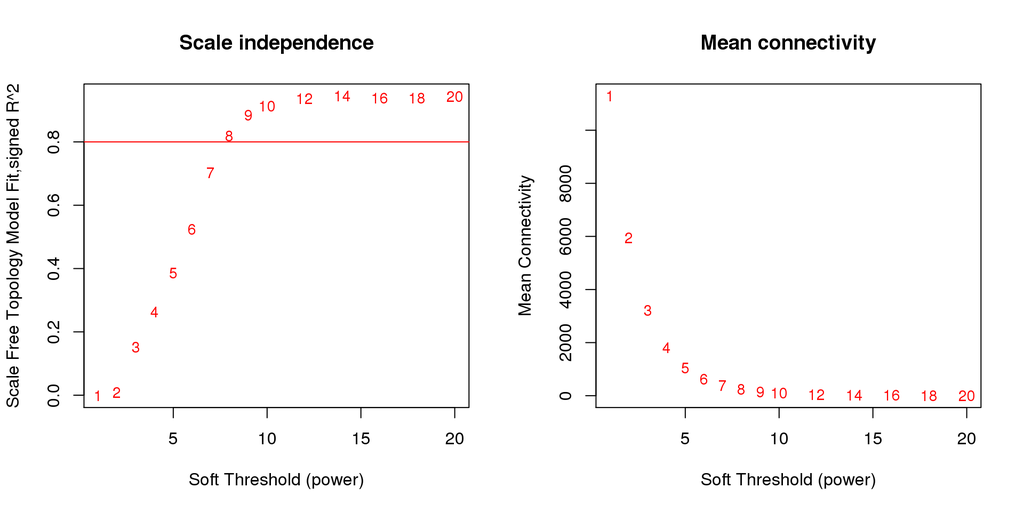

Use a soft-thresholding power of **9** to generate an adjaceny matrix of the network this threshold produces. Then generate a topological overlap matrix from the adjacency matrix using a block-wise approach.

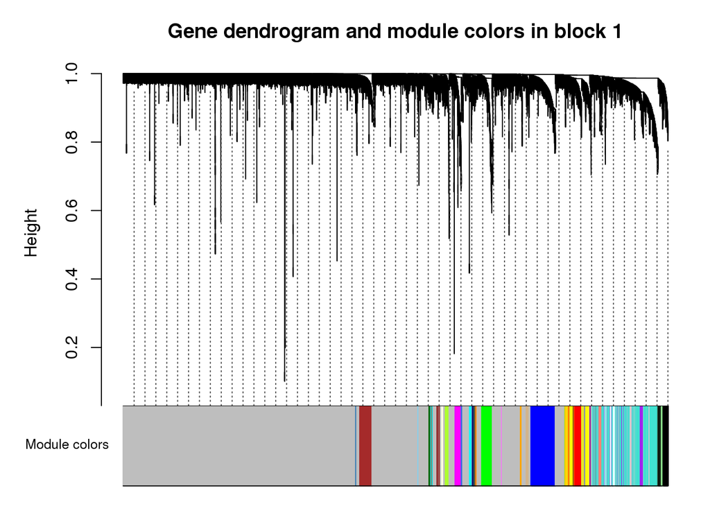

Look at correlations between the module eigengenes.

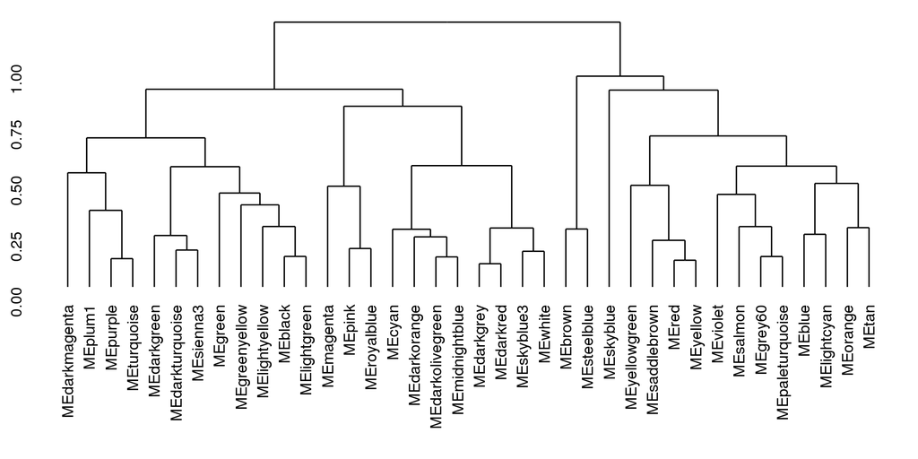

After filtering a total of **22201** genes were included in module identification. These were clustered into modules by splitting data into **1** blocks. A total of **38** modules were identified (plus an additional unassigned module (grey)).

## Module correlations with metadata

Find correlation between module eigengenes and metadata traits. Find modules associated with inflammation.

**Modules/traits with at least one FDR significant correlation (FDR p<0.05)**

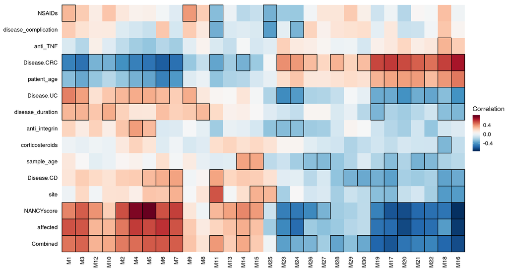

```
## which will replace the existing scale.
```

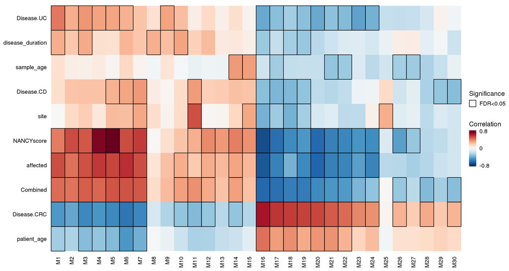

It is clear that the modules are largely correlating with differences in inflammation status. Especially given the FDR adjusted p-values. Nicely, the medication traits are showing opposing effects. The only traits with no nominally significant module associations were **immunosuppression**. The only modules with no significant associations were **M35, M36**.

## **GO Term enrichment analysis of modules**

```
##     ..putting together terms with highest enrichment significance..
```

A total of **15560** were mapped to Entrez gene IDs and used for the GO enrichment analysis. This was performed across **39** keeping the top 10 enriched terms. Results for some modules of interest are shown below.

### Modules postively correlated with NANCY score (FDR p<0.05)

|  | module | modSize | enrichmentP | BonferoniP | termID | termName |
| --- | --- | --- | --- | --- | --- | --- |
| GO:0015370 | M11 | 222 | 0 | 3.00e-07 | GO:0015370 | solute:sodium symporter activity |
| GO:0006629 | M11 | 222 | 0 | 4.00e-07 | GO:0006629 | lipid metabolic process |
| GO:0019433 | M11 | 222 | 0 | 3.20e-06 | GO:0019433 | triglyceride catabolic process |
| GO:0006641 | M11 | 222 | 0 | 3.70e-06 | GO:0006641 | triglyceride metabolic process |
| GO:0031224 | M11 | 222 | 0 | 9.90e-06 | GO:0031224 | intrinsic component of membrane |
| GO:0016324 | M11 | 222 | 0 | 1.13e-05 | GO:0016324 | apical plasma membrane |
| GO:0034378 | M11 | 222 | 0 | 1.21e-05 | GO:0034378 | chylomicron assembly |
| GO:0044281 | M11 | 222 | 0 | 1.25e-05 | GO:0044281 | small molecule metabolic process |
| GO:0045177 | M11 | 222 | 0 | 1.38e-05 | GO:0045177 | apical part of cell |
| GO:0046464 | M11 | 222 | 0 | 2.08e-05 | GO:0046464 | acylglycerol catabolic process |

|  | module | modSize | enrichmentP | BonferoniP | termID | termName |
| --- | --- | --- | --- | --- | --- | --- |
| GO:0050911 | M14 | 153 | 0 | 0.0e+00 | GO:0050911 | detection of chemical stimulus involved in sensory perception of smell |
| GO:0004984 | M14 | 153 | 0 | 0.0e+00 | GO:0004984 | olfactory receptor activity |
| GO:0050907 | M14 | 153 | 0 | 0.0e+00 | GO:0050907 | detection of chemical stimulus involved in sensory perception |
| GO:0007608 | M14 | 153 | 0 | 0.0e+00 | GO:0007608 | sensory perception of smell |
| GO:0050906 | M14 | 153 | 0 | 0.0e+00 | GO:0050906 | detection of stimulus involved in sensory perception |
| GO:0009593 | M14 | 153 | 0 | 0.0e+00 | GO:0009593 | detection of chemical stimulus |
| GO:0007606 | M14 | 153 | 0 | 0.0e+00 | GO:0007606 | sensory perception of chemical stimulus |
| GO:0004930 | M14 | 153 | 0 | 0.0e+00 | GO:0004930 | G-protein coupled receptor activity |
| GO:0051606 | M14 | 153 | 0 | 0.0e+00 | GO:0051606 | detection of stimulus |
| GO:0007600 | M14 | 153 | 0 | 5.2e-06 | GO:0007600 | sensory perception |

|  | module | modSize | enrichmentP | BonferoniP | termID | termName |
| --- | --- | --- | --- | --- | --- | --- |
| GO:0048172 | M15 | 18 | 0.0000879 | 1 | GO:0048172 | regulation of short-term neuronal synaptic plasticity |
| GO:0010824 | M15 | 18 | 0.0008717 | 1 | GO:0010824 | regulation of centrosome duplication |
| GO:0048168 | M15 | 18 | 0.0011769 | 1 | GO:0048168 | regulation of neuronal synaptic plasticity |
| GO:0097310 | M15 | 18 | 0.0011918 | 1 | GO:0097310 | cap2 mRNA methylation |
| GO:0098924 | M15 | 18 | 0.0011918 | 1 | GO:0098924 | retrograde trans-synaptic signaling by nitric oxide |
| GO:0140196 | M15 | 18 | 0.0011918 | 1 | GO:0140196 | positive regulation of adenylate cyclase-activating adrenergic receptor signaling pathway involved in heart process |
| GO:0031723 | M15 | 18 | 0.0011918 | 1 | GO:0031723 | CXCR4 chemokine receptor binding |
| GO:0051966 | M15 | 18 | 0.0015262 | 1 | GO:0051966 | regulation of synaptic transmission, glutamatergic |
| GO:0014069 | M15 | 18 | 0.0015436 | 1 | GO:0014069 | postsynaptic density |
| GO:0099572 | M15 | 18 | 0.0015662 | 1 | GO:0099572 | postsynaptic specialization |

|  | module | modSize | enrichmentP | BonferoniP | termID | termName |
| --- | --- | --- | --- | --- | --- | --- |
| GO:0030970 | M12 | 27 | 1.00e-07 | 0.0024269 | GO:0030970 | retrograde protein transport, ER to cytosol |
| GO:00349761 | M12 | 27 | 2.00e-07 | 0.0042410 | GO:0034976 | response to endoplasmic reticulum stress |
| GO:0032527 | M12 | 27 | 6.00e-07 | 0.0106818 | GO:0032527 | protein exit from endoplasmic reticulum |
| GO:1903573 | M12 | 27 | 7.00e-07 | 0.0130521 | GO:1903573 | negative regulation of response to endoplasmic reticulum stress |
| GO:00057831 | M12 | 27 | 5.20e-06 | 0.0918962 | GO:0005783 | endoplasmic reticulum |
| GO:1904292 | M12 | 27 | 1.29e-05 | 0.2277447 | GO:1904292 | regulation of ERAD pathway |
| GO:0005789 | M12 | 27 | 1.65e-05 | 0.2913028 | GO:0005789 | endoplasmic reticulum membrane |
| GO:0036503 | M12 | 27 | 1.82e-05 | 0.3208003 | GO:0036503 | ERAD pathway |
| GO:0042175 | M12 | 27 | 1.89e-05 | 0.3334264 | GO:0042175 | nuclear outer membrane-endoplasmic reticulum membrane network |
| GO:0050864 | M12 | 27 | 2.52e-05 | 0.4444352 | GO:0050864 | regulation of B cell activation |

|  | module | modSize | enrichmentP | BonferoniP | termID | termName |
| --- | --- | --- | --- | --- | --- | --- |
| GO:00487311 | M13 | 40 | 0.00e+00 | 0.0000007 | GO:0048731 | system development |
| GO:00072751 | M13 | 40 | 0.00e+00 | 0.0000151 | GO:0007275 | multicellular organism development |
| GO:0048856 | M13 | 40 | 0.00e+00 | 0.0001546 | GO:0048856 | anatomical structure development |
| GO:0032502 | M13 | 40 | 1.00e-07 | 0.0009266 | GO:0032502 | developmental process |
| GO:0048513 | M13 | 40 | 1.00e-07 | 0.0021966 | GO:0048513 | animal organ development |
| GO:00073991 | M13 | 40 | 2.50e-06 | 0.0447407 | GO:0007399 | nervous system development |
| GO:00096531 | M13 | 40 | 3.60e-06 | 0.0635976 | GO:0009653 | anatomical structure morphogenesis |
| GO:0015837 | M13 | 40 | 1.12e-05 | 0.1987216 | GO:0015837 | amine transport |
| GO:0030154 | M13 | 40 | 1.44e-05 | 0.2548556 | GO:0030154 | cell differentiation |
| GO:0048468 | M13 | 40 | 1.48e-05 | 0.2612271 | GO:0048468 | cell development |

|  | module | modSize | enrichmentP | BonferoniP | termID | termName |
| --- | --- | --- | --- | --- | --- | --- |
| GO:0010033 | M1 | 105 | 0 | 0 | GO:0010033 | response to organic substance |
| GO:0071310 | M1 | 105 | 0 | 0 | GO:0071310 | cellular response to organic substance |
| GO:0071345 | M1 | 105 | 0 | 0 | GO:0071345 | cellular response to cytokine stimulus |
| GO:0034097 | M1 | 105 | 0 | 0 | GO:0034097 | response to cytokine |
| GO:00508961 | M1 | 105 | 0 | 0 | GO:0050896 | response to stimulus |
| GO:0010941 | M1 | 105 | 0 | 0 | GO:0010941 | regulation of cell death |
| GO:0032496 | M1 | 105 | 0 | 0 | GO:0032496 | response to lipopolysaccharide |
| GO:0009893 | M1 | 105 | 0 | 0 | GO:0009893 | positive regulation of metabolic process |
| GO:0031325 | M1 | 105 | 0 | 0 | GO:0031325 | positive regulation of cellular metabolic process |
| GO:0002237 | M1 | 105 | 0 | 0 | GO:0002237 | response to molecule of bacterial origin |

|  | module | modSize | enrichmentP | BonferoniP | termID | termName |
| --- | --- | --- | --- | --- | --- | --- |
| GO:0030198 | M2 | 91 | 0 | 0 | GO:0030198 | extracellular matrix organization |
| GO:0043062 | M2 | 91 | 0 | 0 | GO:0043062 | extracellular structure organization |
| GO:0032963 | M2 | 91 | 0 | 0 | GO:0032963 | collagen metabolic process |
| GO:0005578 | M2 | 91 | 0 | 0 | GO:0005578 | proteinaceous extracellular matrix |
| GO:0031012 | M2 | 91 | 0 | 0 | GO:0031012 | extracellular matrix |
| GO:0030574 | M2 | 91 | 0 | 0 | GO:0030574 | collagen catabolic process |
| GO:0005201 | M2 | 91 | 0 | 0 | GO:0005201 | extracellular matrix structural constituent |
| GO:0005581 | M2 | 91 | 0 | 0 | GO:0005581 | collagen trimer |
| GO:0005576 | M2 | 91 | 0 | 0 | GO:0005576 | extracellular region |
| GO:0005788 | M2 | 91 | 0 | 0 | GO:0005788 | endoplasmic reticulum lumen |

|  | module | modSize | enrichmentP | BonferoniP | termID | termName |
| --- | --- | --- | --- | --- | --- | --- |
| GO:0048646 | M4 | 44 | 0e+00 | 0.0000002 | GO:0048646 | anatomical structure formation involved in morphogenesis |
| GO:00055761 | M4 | 44 | 0e+00 | 0.0000073 | GO:0005576 | extracellular region |
| GO:0005615 | M4 | 44 | 0e+00 | 0.0001455 | GO:0005615 | extracellular space |
| GO:0001525 | M4 | 44 | 0e+00 | 0.0004739 | GO:0001525 | angiogenesis |
| GO:0035239 | M4 | 44 | 1e-07 | 0.0010279 | GO:0035239 | tube morphogenesis |
| GO:0009653 | M4 | 44 | 1e-07 | 0.0017271 | GO:0009653 | anatomical structure morphogenesis |
| GO:0048514 | M4 | 44 | 1e-07 | 0.0022752 | GO:0048514 | blood vessel morphogenesis |
| GO:00301981 | M4 | 44 | 1e-07 | 0.0026324 | GO:0030198 | extracellular matrix organization |
| GO:0050663 | M4 | 44 | 4e-07 | 0.0066883 | GO:0050663 | cytokine secretion |
| GO:0001568 | M4 | 44 | 5e-07 | 0.0083716 | GO:0001568 | blood vessel development |

|  | module | modSize | enrichmentP | BonferoniP | termID | termName |
| --- | --- | --- | --- | --- | --- | --- |
| GO:0046649 | M6 | 827 | 0 | 0 | GO:0046649 | lymphocyte activation |
| GO:0002376 | M6 | 827 | 0 | 0 | GO:0002376 | immune system process |
| GO:0006955 | M6 | 827 | 0 | 0 | GO:0006955 | immune response |
| GO:0045321 | M6 | 827 | 0 | 0 | GO:0045321 | leukocyte activation |
| GO:0001775 | M6 | 827 | 0 | 0 | GO:0001775 | cell activation |
| GO:0042110 | M6 | 827 | 0 | 0 | GO:0042110 | T cell activation |
| GO:0002682 | M6 | 827 | 0 | 0 | GO:0002682 | regulation of immune system process |
| GO:0002250 | M6 | 827 | 0 | 0 | GO:0002250 | adaptive immune response |
| GO:0002684 | M6 | 827 | 0 | 0 | GO:0002684 | positive regulation of immune system process |
| GO:0050776 | M6 | 827 | 0 | 0 | GO:0050776 | regulation of immune response |

|  | module | modSize | enrichmentP | BonferoniP | termID | termName |
| --- | --- | --- | --- | --- | --- | --- |
| GO:0035556 | M3 | 95 | 0.0000095 | 0.1670318 | GO:0035556 | intracellular signal transduction |
| GO:0065009 | M3 | 95 | 0.0000210 | 0.3702079 | GO:0065009 | regulation of molecular function |
| GO:0007165 | M3 | 95 | 0.0000538 | 0.9506112 | GO:0007165 | signal transduction |
| GO:0007009 | M3 | 95 | 0.0000790 | 1.0000000 | GO:0007009 | plasma membrane organization |
| GO:0030449 | M3 | 95 | 0.0000794 | 1.0000000 | GO:0030449 | regulation of complement activation |
| GO:1902949 | M3 | 95 | 0.0001145 | 1.0000000 | GO:1902949 | positive regulation of tau-protein kinase activity |
| GO:1902531 | M3 | 95 | 0.0001320 | 1.0000000 | GO:1902531 | regulation of intracellular signal transduction |
| GO:0035089 | M3 | 95 | 0.0001490 | 1.0000000 | GO:0035089 | establishment of apical/basal cell polarity |
| GO:0061162 | M3 | 95 | 0.0002105 | 1.0000000 | GO:0061162 | establishment of monopolar cell polarity |
| GO:0097242 | M3 | 95 | 0.0002105 | 1.0000000 | GO:0097242 | amyloid-beta clearance |

|  | module | modSize | enrichmentP | BonferoniP | termID | termName |
| --- | --- | --- | --- | --- | --- | --- |
| GO:00023761 | M5 | 61 | 0 | 0 | GO:0002376 | immune system process |
| GO:00069551 | M5 | 61 | 0 | 0 | GO:0006955 | immune response |
| GO:0006952 | M5 | 61 | 0 | 0 | GO:0006952 | defense response |
| GO:0046903 | M5 | 61 | 0 | 0 | GO:0046903 | secretion |
| GO:0050896 | M5 | 61 | 0 | 0 | GO:0050896 | response to stimulus |
| GO:0032940 | M5 | 61 | 0 | 0 | GO:0032940 | secretion by cell |
| GO:00026821 | M5 | 61 | 0 | 0 | GO:0002682 | regulation of immune system process |
| GO:00026841 | M5 | 61 | 0 | 0 | GO:0002684 | positive regulation of immune system process |
| GO:0042119 | M5 | 61 | 0 | 0 | GO:0042119 | neutrophil activation |
| GO:0002446 | M5 | 61 | 0 | 0 | GO:0002446 | neutrophil mediated immunity |

|  | module | modSize | enrichmentP | BonferoniP | termID | termName |
| --- | --- | --- | --- | --- | --- | --- |
| GO:00069521 | M7 | 118 | 0 | 0 | GO:0006952 | defense response |
| GO:0045087 | M7 | 118 | 0 | 0 | GO:0045087 | innate immune response |
| GO:00069552 | M7 | 118 | 0 | 0 | GO:0006955 | immune response |
| GO:00023762 | M7 | 118 | 0 | 0 | GO:0002376 | immune system process |
| GO:0019221 | M7 | 118 | 0 | 0 | GO:0019221 | cytokine-mediated signaling pathway |
| GO:00340971 | M7 | 118 | 0 | 0 | GO:0034097 | response to cytokine |
| GO:0006950 | M7 | 118 | 0 | 0 | GO:0006950 | response to stress |
| GO:0060337 | M7 | 118 | 0 | 0 | GO:0060337 | type I interferon signaling pathway |
| GO:0071357 | M7 | 118 | 0 | 0 | GO:0071357 | cellular response to type I interferon |
| GO:00713451 | M7 | 118 | 0 | 0 | GO:0071345 | cellular response to cytokine stimulus |

### Modules negatively correlated with NANCY score (FDR p<0.05)

|  | module | modSize | enrichmentP | BonferoniP | termID | termName |
| --- | --- | --- | --- | --- | --- | --- |
| GO:0009312 | M18 | 37 | 0.0000646 | 1 | GO:0009312 | oligosaccharide biosynthetic process |
| GO:0016051 | M18 | 37 | 0.0001021 | 1 | GO:0016051 | carbohydrate biosynthetic process |
| GO:0016757 | M18 | 37 | 0.0002498 | 1 | GO:0016757 | transferase activity, transferring glycosyl groups |
| GO:0005975 | M18 | 37 | 0.0002751 | 1 | GO:0005975 | carbohydrate metabolic process |
| GO:0005922 | M18 | 37 | 0.0002998 | 1 | GO:0005922 | connexin complex |
| GO:0004867 | M18 | 37 | 0.0003331 | 1 | GO:0004867 | serine-type endopeptidase inhibitor activity |
| GO:0008499 | M18 | 37 | 0.0004937 | 1 | GO:0008499 | UDP-galactose:beta-N-acetylglucosamine beta-1,3-galactosyltransferase activity |
| GO:0009311 | M18 | 37 | 0.0005366 | 1 | GO:0009311 | oligosaccharide metabolic process |
| GO:0097503 | M18 | 37 | 0.0008252 | 1 | GO:0097503 | sialylation |
| GO:0008373 | M18 | 37 | 0.0008252 | 1 | GO:0008373 | sialyltransferase activity |

|  | module | modSize | enrichmentP | BonferoniP | termID | termName |
| --- | --- | --- | --- | --- | --- | --- |
| GO:00061191 | M23 | 22 | 0 | 0 | GO:0006119 | oxidative phosphorylation |
| GO:00427751 | M23 | 22 | 0 | 0 | GO:0042775 | mitochondrial ATP synthesis coupled electron transport |
| GO:00427731 | M23 | 22 | 0 | 0 | GO:0042773 | ATP synthesis coupled electron transport |
| GO:00704691 | M23 | 22 | 0 | 0 | GO:0070469 | respiratory chain |
| GO:0022904 | M23 | 22 | 0 | 0 | GO:0022904 | respiratory electron transport chain |
| GO:0046034 | M23 | 22 | 0 | 0 | GO:0046034 | ATP metabolic process |
| GO:00057461 | M23 | 22 | 0 | 0 | GO:0005746 | mitochondrial respiratory chain |
| GO:0022900 | M23 | 22 | 0 | 0 | GO:0022900 | electron transport chain |
| GO:0045333 | M23 | 22 | 0 | 0 | GO:0045333 | cellular respiration |
| GO:0006091 | M23 | 22 | 0 | 0 | GO:0006091 | generation of precursor metabolites and energy |

|  | module | modSize | enrichmentP | BonferoniP | termID | termName |
| --- | --- | --- | --- | --- | --- | --- |
| GO:0006811 | M16 | 183 | 0.0e+00 | 0.0000660 | GO:0006811 | ion transport |
| GO:0015701 | M16 | 183 | 0.0e+00 | 0.0003132 | GO:0015701 | bicarbonate transport |
| GO:0006820 | M16 | 183 | 1.0e-07 | 0.0012740 | GO:0006820 | anion transport |
| GO:0004089 | M16 | 183 | 3.0e-07 | 0.0045284 | GO:0004089 | carbonate dehydratase activity |
| GO:0015711 | M16 | 183 | 6.0e-07 | 0.0101257 | GO:0015711 | organic anion transport |
| GO:0015075 | M16 | 183 | 7.0e-07 | 0.0122706 | GO:0015075 | ion transmembrane transporter activity |
| GO:0005215 | M16 | 183 | 8.0e-07 | 0.0138179 | GO:0005215 | transporter activity |
| GO:0015280 | M16 | 183 | 1.3e-06 | 0.0222378 | GO:0015280 | ligand-gated sodium channel activity |
| GO:0006065 | M16 | 183 | 1.6e-06 | 0.0284456 | GO:0006065 | UDP-glucuronate biosynthetic process |
| GO:0022857 | M16 | 183 | 1.7e-06 | 0.0302996 | GO:0022857 | transmembrane transporter activity |

|  | module | modSize | enrichmentP | BonferoniP | termID | termName |
| --- | --- | --- | --- | --- | --- | --- |
| GO:00160201 | M20 | 1613 | 0 | 0.00e+00 | GO:0016020 | membrane |
| GO:00442813 | M20 | 1613 | 0 | 0.00e+00 | GO:0044281 | small molecule metabolic process |
| GO:0071944 | M20 | 1613 | 0 | 4.00e-07 | GO:0071944 | cell periphery |
| GO:00442551 | M20 | 1613 | 0 | 8.00e-07 | GO:0044255 | cellular lipid metabolic process |
| GO:00066292 | M20 | 1613 | 0 | 2.30e-06 | GO:0006629 | lipid metabolic process |
| GO:0005886 | M20 | 1613 | 0 | 2.30e-06 | GO:0005886 | plasma membrane |
| GO:00160211 | M20 | 1613 | 0 | 1.63e-05 | GO:0016021 | integral component of membrane |
| GO:0006082 | M20 | 1613 | 0 | 2.64e-05 | GO:0006082 | organic acid metabolic process |
| GO:0043296 | M20 | 1613 | 0 | 3.69e-05 | GO:0043296 | apical junction complex |
| GO:00312242 | M20 | 1613 | 0 | 3.73e-05 | GO:0031224 | intrinsic component of membrane |

|  | module | modSize | enrichmentP | BonferoniP | termID | termName |
| --- | --- | --- | --- | --- | --- | --- |
| GO:00057391 | M26 | 128 | 7.00e-07 | 0.0119195 | GO:0005739 | mitochondrion |
| GO:0006414 | M26 | 128 | 1.40e-06 | 0.0243828 | GO:0006414 | translational elongation |
| GO:0070125 | M26 | 128 | 7.60e-06 | 0.1340342 | GO:0070125 | mitochondrial translational elongation |
| GO:0043231 | M26 | 128 | 2.03e-05 | 0.3585950 | GO:0043231 | intracellular membrane-bounded organelle |
| GO:0006415 | M26 | 128 | 2.16e-05 | 0.3823529 | GO:0006415 | translational termination |
| GO:0043227 | M26 | 128 | 4.32e-05 | 0.7634957 | GO:0043227 | membrane-bounded organelle |
| GO:0005762 | M26 | 128 | 6.82e-05 | 1.0000000 | GO:0005762 | mitochondrial large ribosomal subunit |
| GO:0005761 | M26 | 128 | 7.31e-05 | 1.0000000 | GO:0005761 | mitochondrial ribosome |
| GO:0005759 | M26 | 128 | 7.39e-05 | 1.0000000 | GO:0005759 | mitochondrial matrix |
| GO:0070126 | M26 | 128 | 9.45e-05 | 1.0000000 | GO:0070126 | mitochondrial translational termination |

|  | module | modSize | enrichmentP | BonferoniP | termID | termName |
| --- | --- | --- | --- | --- | --- | --- |
| GO:0005743 | M19 | 304 | 0 | 0 | GO:0005743 | mitochondrial inner membrane |
| GO:0005740 | M19 | 304 | 0 | 0 | GO:0005740 | mitochondrial envelope |
| GO:0019866 | M19 | 304 | 0 | 0 | GO:0019866 | organelle inner membrane |
| GO:0031966 | M19 | 304 | 0 | 0 | GO:0031966 | mitochondrial membrane |
| GO:0005739 | M19 | 304 | 0 | 0 | GO:0005739 | mitochondrion |
| GO:0006119 | M19 | 304 | 0 | 0 | GO:0006119 | oxidative phosphorylation |
| GO:0070469 | M19 | 304 | 0 | 0 | GO:0070469 | respiratory chain |
| GO:0042775 | M19 | 304 | 0 | 0 | GO:0042775 | mitochondrial ATP synthesis coupled electron transport |
| GO:0042773 | M19 | 304 | 0 | 0 | GO:0042773 | ATP synthesis coupled electron transport |
| GO:0005746 | M19 | 304 | 0 | 0 | GO:0005746 | mitochondrial respiratory chain |

|  | module | modSize | enrichmentP | BonferoniP | termID | termName |
| --- | --- | --- | --- | --- | --- | --- |
| GO:00057431 | M17 | 86 | 0 | 0.0e+00 | GO:0005743 | mitochondrial inner membrane |
| GO:00057401 | M17 | 86 | 0 | 0.0e+00 | GO:0005740 | mitochondrial envelope |
| GO:00198661 | M17 | 86 | 0 | 0.0e+00 | GO:0019866 | organelle inner membrane |
| GO:00319661 | M17 | 86 | 0 | 0.0e+00 | GO:0031966 | mitochondrial membrane |
| GO:00057392 | M17 | 86 | 0 | 0.0e+00 | GO:0005739 | mitochondrion |
| GO:00310901 | M17 | 86 | 0 | 3.0e-07 | GO:0031090 | organelle membrane |
| GO:00701251 | M17 | 86 | 0 | 9.0e-07 | GO:0070125 | mitochondrial translational elongation |
| GO:00701261 | M17 | 86 | 0 | 1.2e-06 | GO:0070126 | mitochondrial translational termination |
| GO:0032543 | M17 | 86 | 0 | 2.8e-06 | GO:0032543 | mitochondrial translation |
| GO:0007005 | M17 | 86 | 0 | 2.9e-06 | GO:0007005 | mitochondrion organization |

|  | module | modSize | enrichmentP | BonferoniP | termID | termName |
| --- | --- | --- | --- | --- | --- | --- |
| GO:00066291 | M24 | 236 | 0e+00 | 0.0000041 | GO:0006629 | lipid metabolic process |
| GO:0044255 | M24 | 236 | 0e+00 | 0.0001129 | GO:0044255 | cellular lipid metabolic process |
| GO:0006631 | M24 | 236 | 0e+00 | 0.0007049 | GO:0006631 | fatty acid metabolic process |
| GO:0032787 | M24 | 236 | 1e-07 | 0.0008937 | GO:0032787 | monocarboxylic acid metabolic process |
| GO:0016042 | M24 | 236 | 1e-07 | 0.0011724 | GO:0016042 | lipid catabolic process |
| GO:0030258 | M24 | 236 | 1e-07 | 0.0012130 | GO:0030258 | lipid modification |
| GO:0009062 | M24 | 236 | 1e-07 | 0.0012717 | GO:0009062 | fatty acid catabolic process |
| GO:0046395 | M24 | 236 | 2e-07 | 0.0038248 | GO:0046395 | carboxylic acid catabolic process |
| GO:0044242 | M24 | 236 | 3e-07 | 0.0049126 | GO:0044242 | cellular lipid catabolic process |
| GO:00442811 | M24 | 236 | 4e-07 | 0.0063582 | GO:0044281 | small molecule metabolic process |

|  | module | modSize | enrichmentP | BonferoniP | termID | termName |
| --- | --- | --- | --- | --- | --- | --- |
| GO:0031090 | M27 | 74 | 0.0000065 | 0.1157315 | GO:0031090 | organelle membrane |
| GO:0034976 | M27 | 74 | 0.0002938 | 1.0000000 | GO:0034976 | response to endoplasmic reticulum stress |
| GO:0044424 | M27 | 74 | 0.0003088 | 1.0000000 | GO:0044424 | intracellular part |
| GO:0016197 | M27 | 74 | 0.0003187 | 1.0000000 | GO:0016197 | endosomal transport |
| GO:2001199 | M27 | 74 | 0.0003413 | 1.0000000 | GO:2001199 | negative regulation of dendritic cell differentiation |
| GO:0070765 | M27 | 74 | 0.0003413 | 1.0000000 | GO:0070765 | gamma-secretase complex |
| GO:0031410 | M27 | 74 | 0.0004450 | 1.0000000 | GO:0031410 | cytoplasmic vesicle |
| GO:0097708 | M27 | 74 | 0.0004510 | 1.0000000 | GO:0097708 | intracellular vesicle |
| GO:0042147 | M27 | 74 | 0.0005207 | 1.0000000 | GO:0042147 | retrograde transport, endosome to Golgi |
| GO:0012505 | M27 | 74 | 0.0005550 | 1.0000000 | GO:0012505 | endomembrane system |

|  | module | modSize | enrichmentP | BonferoniP | termID | termName |
| --- | --- | --- | --- | --- | --- | --- |
| GO:0019068 | M21 | 32 | 9.00e-07 | 0.0161620 | GO:0019068 | virion assembly |
| GO:0000815 | M21 | 32 | 1.70e-06 | 0.0300589 | GO:0000815 | ESCRT III complex |
| GO:1902188 | M21 | 32 | 3.50e-06 | 0.0619084 | GO:1902188 | positive regulation of viral release from host cell |
| GO:0000920 | M21 | 32 | 5.20e-06 | 0.0922654 | GO:0000920 | cell separation after cytokinesis |
| GO:0039702 | M21 | 32 | 1.02e-05 | 0.1794591 | GO:0039702 | viral budding via host ESCRT complex |
| GO:0046755 | M21 | 32 | 1.54e-05 | 0.2719647 | GO:0046755 | viral budding |
| GO:0036258 | M21 | 32 | 3.06e-05 | 0.5410098 | GO:0036258 | multivesicular body assembly |
| GO:0036257 | M21 | 32 | 3.39e-05 | 0.5981430 | GO:0036257 | multivesicular body organization |
| GO:1902186 | M21 | 32 | 3.39e-05 | 0.5981430 | GO:1902186 | regulation of viral release from host cell |
| GO:0019076 | M21 | 32 | 4.90e-05 | 0.8661045 | GO:0019076 | viral release from host cell |

|  | module | modSize | enrichmentP | BonferoniP | termID | termName |
| --- | --- | --- | --- | --- | --- | --- |
| GO:00057393 | M22 | 54 | 0.0000894 | 1 | GO:0005739 | mitochondrion |
| GO:00057591 | M22 | 54 | 0.0001387 | 1 | GO:0005759 | mitochondrial matrix |
| GO:0016421 | M22 | 54 | 0.0001796 | 1 | GO:0016421 | CoA carboxylase activity |
| GO:0055114 | M22 | 54 | 0.0002091 | 1 | GO:0055114 | oxidation-reduction process |
| GO:0016885 | M22 | 54 | 0.0003338 | 1 | GO:0016885 | ligase activity, forming carbon-carbon bonds |
| GO:00090621 | M22 | 54 | 0.0004971 | 1 | GO:0009062 | fatty acid catabolic process |
| GO:0045598 | M22 | 54 | 0.0005153 | 1 | GO:0045598 | regulation of fat cell differentiation |
| GO:00442421 | M22 | 54 | 0.0005515 | 1 | GO:0044242 | cellular lipid catabolic process |
| GO:0006768 | M22 | 54 | 0.0006512 | 1 | GO:0006768 | biotin metabolic process |
| GO:0005777 | M22 | 54 | 0.0008218 | 1 | GO:0005777 | peroxisome |

## **Summary of output files**

*discovery_module_analysis.html* - This report showing all the steps in the analysis.

*discovery_WGCNAgeneInfo.csv* - Table showing the module assignment for each gene, its correlation with inflammation, and its correlation with all other modules.

*discovery_WGCNAmodInfo.csv* - Table showing the module correlations with all clinical traits including inflammation.

*discovery_WGCNAGOEnrcihmentTable.csv* - Table contianing the top 10 GO terms enriched for in each module.

*TOM-block.-.Rds* - Topological overlap matrices used to generate the modules (generated blockwise).

*discovery_filtered_tpm.Rds* - The TPMs after filtering used to make the modules. Passed to the network script to name the genes.

*discovery_NANCY_module_correlations.tsv* - Eigengene correlation values and significance for each module vs NANCY scores.

Additional plots not included in the markdown are network plots of the gene networks within each module, which are in Plots/Networks at various TOM thresholds.